# Risk Factor Analysis

## Outcome Variable

**Outcome Variable:** ever_swasted

## Predictor Variables

**Intervention Variable:** exclfeed6

**Adjustment Set:**

- arm
- sex
- brthmon
- W_mage
- meducyrs
- feducyrs
- hhwealth_quart
- hfoodsec
- W_mhtcm
- W_mwtkg
- W_mbmi
- vagbrth
- W_gagebrth
- W_birthwt
- W_birthlen
- W_nrooms
- W_nchldlt5
- month
- W_parity
- impfloor
- impsan
- safeh20
- delta_W_mage
- delta_meducyrs
- delta_feducyrs
- delta_hhwealth_quart
- delta_hfoodsec
- delta_W_mhtcm
- delta_W_mwtkg
- delta_W_mbmi
- delta_vagbrth
- delta_W_gagebrth
- delta_W_birthwt
- delta_W_birthlen
- delta_W_nrooms
- delta_W_nchldlt5
- delta_month
- delta_W_parity
- delta_impfloor
- delta_impsan
- delta_safeh20

## Stratifying Variables

The analysis was stratified on these variable(s):

- agecat
- studyid
- country

## Data Summary

| agecat | studyid | country | exclfeed6 | ever_swasted | n_cell | n |
| --- | --- | --- | --- | --- | --- | --- |
| 0-24 months (no birth wast) | CMC-V-BCS-2002 | INDIA | 1 | 0 | 15 | 19 |
| 0-24 months (no birth wast) | CMC-V-BCS-2002 | INDIA | 1 | 1 | 4 | 19 |
| 0-24 months (no birth wast) | CMC-V-BCS-2002 | INDIA | 0 | 0 | 0 | 19 |
| 0-24 months (no birth wast) | CMC-V-BCS-2002 | INDIA | 0 | 1 | 0 | 19 |
| 0-24 months (no birth wast) | EE | PAKISTAN | 1 | 0 | 38 | 48 |
| 0-24 months (no birth wast) | EE | PAKISTAN | 1 | 1 | 5 | 48 |
| 0-24 months (no birth wast) | EE | PAKISTAN | 0 | 0 | 4 | 48 |
| 0-24 months (no birth wast) | EE | PAKISTAN | 0 | 1 | 1 | 48 |
| 0-24 months (no birth wast) | GMS-Nepal | NEPAL | 1 | 0 | 330 | 560 |
| 0-24 months (no birth wast) | GMS-Nepal | NEPAL | 1 | 1 | 87 | 560 |
| 0-24 months (no birth wast) | GMS-Nepal | NEPAL | 0 | 0 | 104 | 560 |
| 0-24 months (no birth wast) | GMS-Nepal | NEPAL | 0 | 1 | 39 | 560 |
| 0-24 months (no birth wast) | IRC | INDIA | 1 | 0 | 0 | 14 |
| 0-24 months (no birth wast) | IRC | INDIA | 1 | 1 | 0 | 14 |
| 0-24 months (no birth wast) | IRC | INDIA | 0 | 0 | 9 | 14 |
| 0-24 months (no birth wast) | IRC | INDIA | 0 | 1 | 5 | 14 |
| 0-24 months (no birth wast) | JiVitA-3 | BANGLADESH | 1 | 0 | 11752 | 15666 |
| 0-24 months (no birth wast) | JiVitA-3 | BANGLADESH | 1 | 1 | 433 | 15666 |
| 0-24 months (no birth wast) | JiVitA-3 | BANGLADESH | 0 | 0 | 3358 | 15666 |
| 0-24 months (no birth wast) | JiVitA-3 | BANGLADESH | 0 | 1 | 123 | 15666 |
| 0-24 months (no birth wast) | JiVitA-4 | BANGLADESH | 1 | 0 | 3519 | 4722 |
| 0-24 months (no birth wast) | JiVitA-4 | BANGLADESH | 1 | 1 | 147 | 4722 |
| 0-24 months (no birth wast) | JiVitA-4 | BANGLADESH | 0 | 0 | 1005 | 4722 |
| 0-24 months (no birth wast) | JiVitA-4 | BANGLADESH | 0 | 1 | 51 | 4722 |
| 0-24 months (no birth wast) | Keneba | GAMBIA | 1 | 0 | 722 | 2226 |
| 0-24 months (no birth wast) | Keneba | GAMBIA | 1 | 1 | 101 | 2226 |
| 0-24 months (no birth wast) | Keneba | GAMBIA | 0 | 0 | 1159 | 2226 |
| 0-24 months (no birth wast) | Keneba | GAMBIA | 0 | 1 | 244 | 2226 |
| 0-24 months (no birth wast) | LCNI-5 | MALAWI | 1 | 0 | 47 | 271 |
| 0-24 months (no birth wast) | LCNI-5 | MALAWI | 1 | 1 | 0 | 271 |
| 0-24 months (no birth wast) | LCNI-5 | MALAWI | 0 | 0 | 222 | 271 |
| 0-24 months (no birth wast) | LCNI-5 | MALAWI | 0 | 1 | 2 | 271 |
| 0-24 months (no birth wast) | MAL-ED | BANGLADESH | 1 | 0 | 31 | 233 |
| 0-24 months (no birth wast) | MAL-ED | BANGLADESH | 1 | 1 | 2 | 233 |
| 0-24 months (no birth wast) | MAL-ED | BANGLADESH | 0 | 0 | 190 | 233 |
| 0-24 months (no birth wast) | MAL-ED | BANGLADESH | 0 | 1 | 10 | 233 |
| 0-24 months (no birth wast) | MAL-ED | BRAZIL | 1 | 0 | 12 | 210 |
| 0-24 months (no birth wast) | MAL-ED | BRAZIL | 1 | 1 | 0 | 210 |
| 0-24 months (no birth wast) | MAL-ED | BRAZIL | 0 | 0 | 194 | 210 |
| 0-24 months (no birth wast) | MAL-ED | BRAZIL | 0 | 1 | 4 | 210 |
| 0-24 months (no birth wast) | MAL-ED | INDIA | 1 | 0 | 2 | 216 |
| 0-24 months (no birth wast) | MAL-ED | INDIA | 1 | 1 | 0 | 216 |
| 0-24 months (no birth wast) | MAL-ED | INDIA | 0 | 0 | 202 | 216 |
| 0-24 months (no birth wast) | MAL-ED | INDIA | 0 | 1 | 12 | 216 |
| 0-24 months (no birth wast) | MAL-ED | NEPAL | 1 | 0 | 5 | 225 |
| 0-24 months (no birth wast) | MAL-ED | NEPAL | 1 | 1 | 0 | 225 |
| 0-24 months (no birth wast) | MAL-ED | NEPAL | 0 | 0 | 217 | 225 |
| 0-24 months (no birth wast) | MAL-ED | NEPAL | 0 | 1 | 3 | 225 |
| 0-24 months (no birth wast) | MAL-ED | PERU | 1 | 0 | 5 | 271 |
| 0-24 months (no birth wast) | MAL-ED | PERU | 1 | 1 | 0 | 271 |
| 0-24 months (no birth wast) | MAL-ED | PERU | 0 | 0 | 262 | 271 |
| 0-24 months (no birth wast) | MAL-ED | PERU | 0 | 1 | 4 | 271 |
| 0-24 months (no birth wast) | MAL-ED | SOUTH AFRICA | 1 | 0 | 0 | 237 |
| 0-24 months (no birth wast) | MAL-ED | SOUTH AFRICA | 1 | 1 | 0 | 237 |
| 0-24 months (no birth wast) | MAL-ED | SOUTH AFRICA | 0 | 0 | 226 | 237 |
| 0-24 months (no birth wast) | MAL-ED | SOUTH AFRICA | 0 | 1 | 11 | 237 |
| 0-24 months (no birth wast) | MAL-ED | TANZANIA, UNITED REPUBLIC OF | 1 | 0 | 0 | 235 |
| 0-24 months (no birth wast) | MAL-ED | TANZANIA, UNITED REPUBLIC OF | 1 | 1 | 0 | 235 |
| 0-24 months (no birth wast) | MAL-ED | TANZANIA, UNITED REPUBLIC OF | 0 | 0 | 227 | 235 |
| 0-24 months (no birth wast) | MAL-ED | TANZANIA, UNITED REPUBLIC OF | 0 | 1 | 8 | 235 |
| 0-24 months (no birth wast) | PROVIDE | BANGLADESH | 1 | 0 | 197 | 687 |
| 0-24 months (no birth wast) | PROVIDE | BANGLADESH | 1 | 1 | 4 | 687 |
| 0-24 months (no birth wast) | PROVIDE | BANGLADESH | 0 | 0 | 471 | 687 |
| 0-24 months (no birth wast) | PROVIDE | BANGLADESH | 0 | 1 | 15 | 687 |
| 0-24 months (no birth wast) | SAS-CompFeed | INDIA | 1 | 0 | 368 | 443 |
| 0-24 months (no birth wast) | SAS-CompFeed | INDIA | 1 | 1 | 53 | 443 |
| 0-24 months (no birth wast) | SAS-CompFeed | INDIA | 0 | 0 | 20 | 443 |
| 0-24 months (no birth wast) | SAS-CompFeed | INDIA | 0 | 1 | 2 | 443 |
| 0-24 months (no birth wast) | SAS-FoodSuppl | INDIA | 1 | 0 | 0 | 173 |
| 0-24 months (no birth wast) | SAS-FoodSuppl | INDIA | 1 | 1 | 0 | 173 |
| 0-24 months (no birth wast) | SAS-FoodSuppl | INDIA | 0 | 0 | 159 | 173 |
| 0-24 months (no birth wast) | SAS-FoodSuppl | INDIA | 0 | 1 | 14 | 173 |

The following strata were considered:

- agecat: 0-24 months (no birth wast), studyid: CMC-V-BCS-2002, country: INDIA
- agecat: 0-24 months (no birth wast), studyid: EE, country: PAKISTAN
- agecat: 0-24 months (no birth wast), studyid: GMS-Nepal, country: NEPAL
- agecat: 0-24 months (no birth wast), studyid: IRC, country: INDIA
- agecat: 0-24 months (no birth wast), studyid: JiVitA-3, country: BANGLADESH
- agecat: 0-24 months (no birth wast), studyid: JiVitA-4, country: BANGLADESH
- agecat: 0-24 months (no birth wast), studyid: Keneba, country: GAMBIA
- agecat: 0-24 months (no birth wast), studyid: LCNI-5, country: MALAWI
- agecat: 0-24 months (no birth wast), studyid: MAL-ED, country: BANGLADESH
- agecat: 0-24 months (no birth wast), studyid: MAL-ED, country: BRAZIL
- agecat: 0-24 months (no birth wast), studyid: MAL-ED, country: INDIA
- agecat: 0-24 months (no birth wast), studyid: MAL-ED, country: NEPAL
- agecat: 0-24 months (no birth wast), studyid: MAL-ED, country: PERU
- agecat: 0-24 months (no birth wast), studyid: MAL-ED, country: SOUTH AFRICA
- agecat: 0-24 months (no birth wast), studyid: MAL-ED, country: TANZANIA, UNITED REPUBLIC OF
- agecat: 0-24 months (no birth wast), studyid: PROVIDE, country: BANGLADESH
- agecat: 0-24 months (no birth wast), studyid: SAS-CompFeed, country: INDIA
- agecat: 0-24 months (no birth wast), studyid: SAS-FoodSuppl, country: INDIA

### Dropped Strata

Some strata were dropped due to rare outcomes:

- agecat: 0-24 months (no birth wast), studyid: CMC-V-BCS-2002, country: INDIA
- agecat: 0-24 months (no birth wast), studyid: EE, country: PAKISTAN
- agecat: 0-24 months (no birth wast), studyid: IRC, country: INDIA
- agecat: 0-24 months (no birth wast), studyid: LCNI-5, country: MALAWI
- agecat: 0-24 months (no birth wast), studyid: MAL-ED, country: BANGLADESH
- agecat: 0-24 months (no birth wast), studyid: MAL-ED, country: BRAZIL
- agecat: 0-24 months (no birth wast), studyid: MAL-ED, country: INDIA
- agecat: 0-24 months (no birth wast), studyid: MAL-ED, country: NEPAL
- agecat: 0-24 months (no birth wast), studyid: MAL-ED, country: PERU
- agecat: 0-24 months (no birth wast), studyid: MAL-ED, country: SOUTH AFRICA
- agecat: 0-24 months (no birth wast), studyid: MAL-ED, country: TANZANIA, UNITED REPUBLIC OF
- agecat: 0-24 months (no birth wast), studyid: PROVIDE, country: BANGLADESH
- agecat: 0-24 months (no birth wast), studyid: SAS-CompFeed, country: INDIA
- agecat: 0-24 months (no birth wast), studyid: SAS-FoodSuppl, country: INDIA

## Methods Detail

We're interested in the causal parameters $E[Y_a]$ for all values of $a \in \mathcal{A}$. These parameters represent the mean outcome if, possibly contrary to fact, we intervened to set all units to have $A=a$. Under the randomization and positivity assumptions, these are identified by the statistical parameters $\psi_a=E_W[E_{Y|A,W}(Y|A=a,W)]$. In addition, we're interested in the mean of $Y$, $E[Y]$ under no intervention (the observed mean). We will estimate these parameters by using SuperLearner to fit the relevant likelihood factors -- $E_{Y|A,W}(Y|A=a,W)$ and $p(A=a|W)$, and then updating our likelihood fit using a joint TMLE.

For unadjusted analyses ($W=\{\}$), initial likelihoods were estimated using Lrnr_glm to estimate the simple $E(Y|A)$ and Lrnr_mean to estimate $p(A)$. For adjusted analyses, a small library containing Lrnr_glmnet, Lrnr_xgboost, and Lrnr_mean was used.

Having estimated these parameters, we will then use the delta method to estimate relative risks and attributable risks relative to a prespecified baseline level of $A$.

# Results Detail

## Results Plots

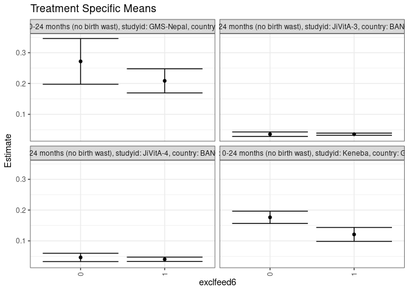

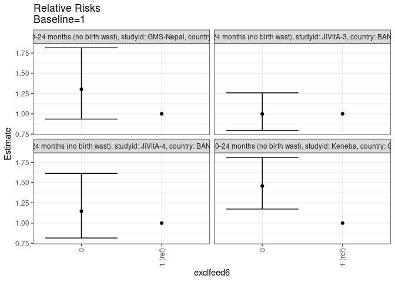

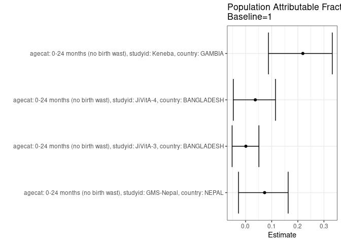

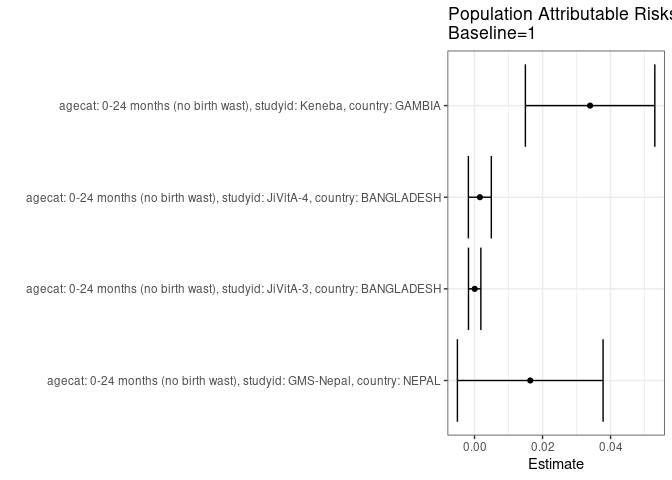

## Results Table

### Parameter: TSM

| agecat | studyid | country | intervention_level | baseline_level | estimate | ci_lower | ci_upper |
| --- | --- | --- | --- | --- | --- | --- | --- |
| 0-24 months (no birth wast) | GMS-Nepal | NEPAL | 1 | NA | 0.2086219 | 0.1694938 | 0.2477501 |
| 0-24 months (no birth wast) | GMS-Nepal | NEPAL | 0 | NA | 0.2717233 | 0.1975137 | 0.3459329 |
| 0-24 months (no birth wast) | JiVitA-3 | BANGLADESH | 1 | NA | 0.0354534 | 0.0318118 | 0.0390950 |
| 0-24 months (no birth wast) | JiVitA-3 | BANGLADESH | 0 | NA | 0.0354013 | 0.0280475 | 0.0427550 |
| 0-24 months (no birth wast) | JiVitA-4 | BANGLADESH | 1 | NA | 0.0403713 | 0.0334041 | 0.0473385 |
| 0-24 months (no birth wast) | JiVitA-4 | BANGLADESH | 0 | NA | 0.0463161 | 0.0329117 | 0.0597205 |
| 0-24 months (no birth wast) | Keneba | GAMBIA | 1 | NA | 0.1210054 | 0.0984200 | 0.1435908 |
| 0-24 months (no birth wast) | Keneba | GAMBIA | 0 | NA | 0.1764742 | 0.1565391 | 0.1964093 |

### Parameter: E(Y)

| agecat | studyid | country | intervention_level | baseline_level | estimate | ci_lower | ci_upper |
| --- | --- | --- | --- | --- | --- | --- | --- |
| 0-24 months (no birth wast) | GMS-Nepal | NEPAL | NA | NA | 0.2250000 | 0.1903834 | 0.2596166 |
| 0-24 months (no birth wast) | JiVitA-3 | BANGLADESH | NA | NA | 0.0354909 | 0.0322227 | 0.0387591 |
| 0-24 months (no birth wast) | JiVitA-4 | BANGLADESH | NA | NA | 0.0419314 | 0.0358274 | 0.0480353 |
| 0-24 months (no birth wast) | Keneba | GAMBIA | NA | NA | 0.1549865 | 0.1399495 | 0.1700235 |

### Parameter: RR

| agecat | studyid | country | intervention_level | baseline_level | estimate | ci_lower | ci_upper |
| --- | --- | --- | --- | --- | --- | --- | --- |
| 0-24 months (no birth wast) | GMS-Nepal | NEPAL | 1 | 1 | 1.0000000 | 1.0000000 | 1.000000 |
| 0-24 months (no birth wast) | GMS-Nepal | NEPAL | 0 | 1 | 1.3024674 | 0.9348391 | 1.814667 |
| 0-24 months (no birth wast) | JiVitA-3 | BANGLADESH | 1 | 1 | 1.0000000 | 1.0000000 | 1.000000 |
| 0-24 months (no birth wast) | JiVitA-3 | BANGLADESH | 0 | 1 | 0.9985286 | 0.7920895 | 1.258771 |
| 0-24 months (no birth wast) | JiVitA-4 | BANGLADESH | 1 | 1 | 1.0000000 | 1.0000000 | 1.000000 |
| 0-24 months (no birth wast) | JiVitA-4 | BANGLADESH | 0 | 1 | 1.1472528 | 0.8161751 | 1.612631 |
| 0-24 months (no birth wast) | Keneba | GAMBIA | 1 | 1 | 1.0000000 | 1.0000000 | 1.000000 |
| 0-24 months (no birth wast) | Keneba | GAMBIA | 0 | 1 | 1.4583994 | 1.1735265 | 1.812425 |

### Parameter: PAR

| agecat | studyid | country | intervention_level | baseline_level | estimate | ci_lower | ci_upper |
| --- | --- | --- | --- | --- | --- | --- | --- |
| 0-24 months (no birth wast) | GMS-Nepal | NEPAL | 1 | NA | 0.0163781 | -0.0050410 | 0.0377972 |
| 0-24 months (no birth wast) | JiVitA-3 | BANGLADESH | 1 | NA | 0.0000375 | -0.0017837 | 0.0018586 |
| 0-24 months (no birth wast) | JiVitA-4 | BANGLADESH | 1 | NA | 0.0015601 | -0.0018150 | 0.0049352 |
| 0-24 months (no birth wast) | Keneba | GAMBIA | 1 | NA | 0.0339811 | 0.0149487 | 0.0530136 |

### Parameter: PAF

| agecat | studyid | country | intervention_level | baseline_level | estimate | ci_lower | ci_upper |
| --- | --- | --- | --- | --- | --- | --- | --- |
| 0-24 months (no birth wast) | GMS-Nepal | NEPAL | 1 | NA | 0.0727914 | -0.0271375 | 0.1629984 |
| 0-24 months (no birth wast) | JiVitA-3 | BANGLADESH | 1 | NA | 0.0010553 | -0.0515915 | 0.0510664 |
| 0-24 months (no birth wast) | JiVitA-4 | BANGLADESH | 1 | NA | 0.0372059 | -0.0469273 | 0.1145780 |
| 0-24 months (no birth wast) | Keneba | GAMBIA | 1 | NA | 0.2192522 | 0.0875189 | 0.3319673 |